# Assignment MP1

```r
#6. Chose an accuracy measure
# I will choose MAPE (Mean Absolute Percentage Error) as the accuracy measure. It is a commonly used metric that measures the accuracy of predicted values by calculating the percentage difference between the predicted and actual values and it is easy to interpret and is used in many forecasting tasks.
```

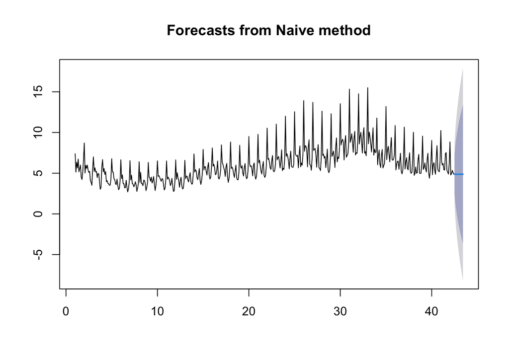

```r
#7. Create a forecast model
#a) Naive model
naive_forecast <- naive(mydata_ts, h = 12)
plot(naive_forecast)
```

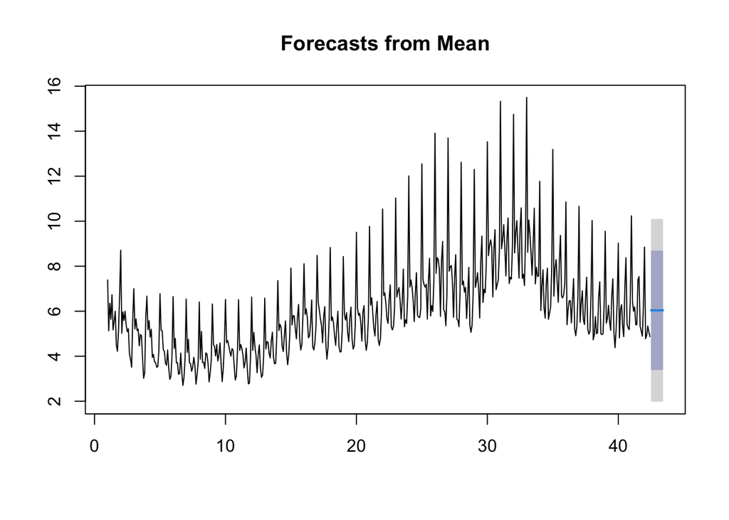

```r
#b)Average model
mean_forecast <- meanf(mydata_ts, h = 12)
plot(mean_forecast)
```

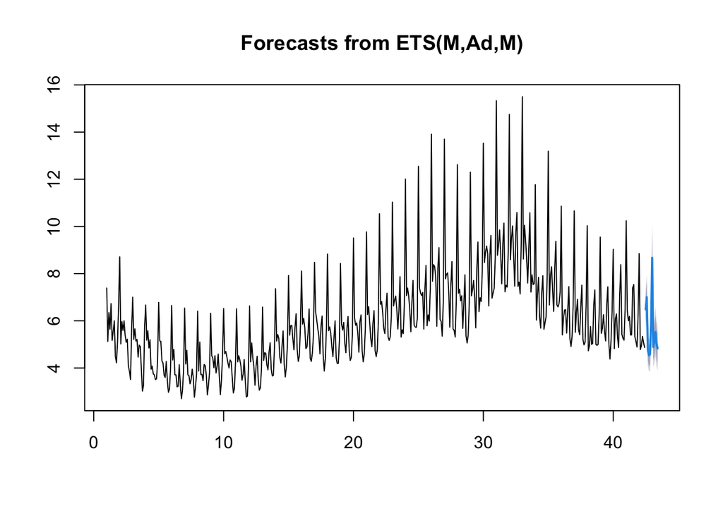

```r
#c)Exponential Smoothing
ets_model <- ets(mydata_ts)
ets_forecast <- forecast(ets_model, h = 12)
plot(ets_forecast)
```

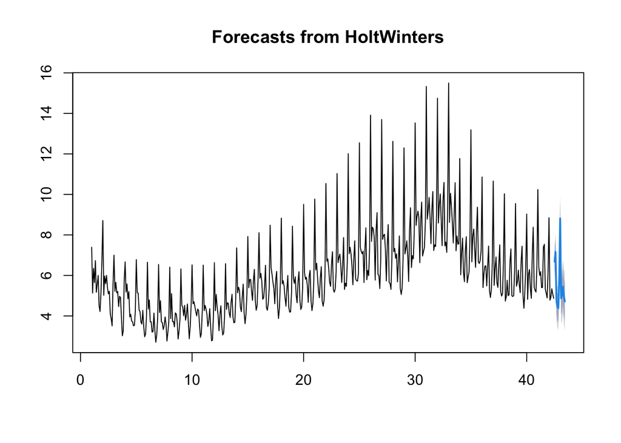

```r
#d)Holt-Winters Model
hw_forecast <- HoltWinters(mydata_ts)
hw_pred <- forecast(hw_forecast, h = 12)
plot(hw_pred)
```

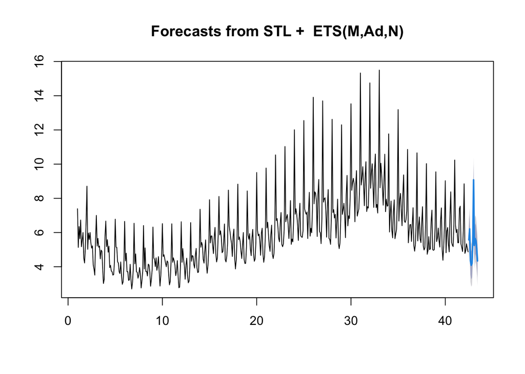

```r
#e)Decomposition Forecast
stl_model <- stl(mydata_ts, s.window = "periodic")
stl_forecast <- forecast(stl_model, h = 12)
plot(stl_forecast)
```

```r
#8. Show model rank with accuracy measures
accuracy_naive <- accuracy(naive_forecast)
accuracy_mean <- accuracy(mean_forecast)
accuracy_ets <- accuracy(ets_model)
accuracy_hw <- accuracy(hw_pred)
accuracy_stl <- accuracy(stl_forecast)

print(accuracy_naive)
```

```
##                        ME     RMSE     MAE       MPE     MAPE     MASE
## Training set -0.005070423 1.921782 1.27839 -3.431347 19.95608 2.617313
##                    ACF1
## Training set -0.3457839
```

```r
print(accuracy_mean)
```

```
##                         ME    RMSE      MAE       MPE     MAPE     MASE
## Training set -1.747821e-16 2.06368 1.549925 -10.72472 27.71948 3.173239
##                   ACF1
## Training set 0.5665141
```

```r
print(accuracy_ets)
```

```
##                       ME      RMSE       MAE        MPE     MAPE      MASE
## Training set -0.00832737 0.4181118 0.2994809 -0.3984877 5.068336 0.6131423
##                   ACF1
## Training set 0.2333164
```

```r
print(accuracy_hw)
```

```
##                      ME      RMSE       MAE        MPE     MAPE      MASE
## Training set 0.01041486 0.4260906 0.3082114 0.09657761 5.211693 0.6310167
##                   ACF1
## Training set 0.1020312
```

```r
print(accuracy_stl)
```

```
##                        ME      RMSE       MAE        MPE     MAPE      MASE
## Training set -0.007169591 0.6663951 0.4646528 -0.5126491 7.742534 0.9513069
##                   ACF1
## Training set 0.1267396
```

```r
#9. Choose which models and how are you going to use them for Forecasting
# I would choose Exponential Smoothing Model as the primary forecasting model since it has the lowest RMSE and MAPE values. Holt-Winters and STL models, which also produced similar forecasts.
```

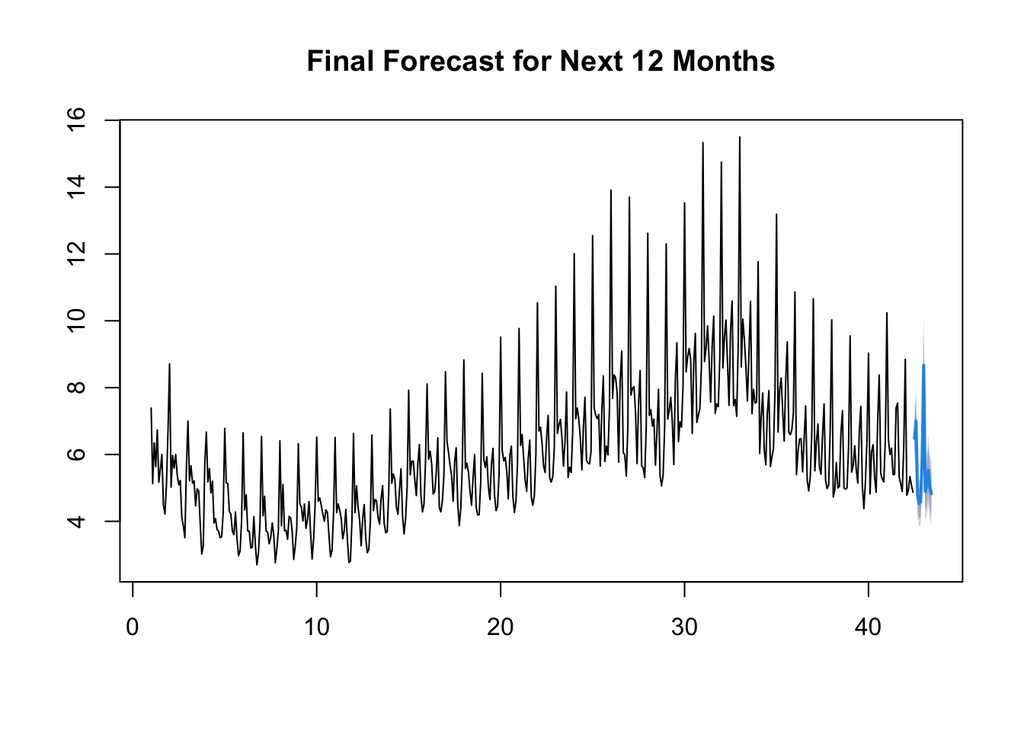

```r
#10. Provide the forecast for the next 12 months
ets_model <- ets(mydata_ts)
ets_forecast <- forecast(ets_model, h = 12)
plot(ets_forecast, main = "Final Forecast for Next 12 Months")
```

```r
print(ets_forecast)
```

```
##        Point Forecast    Lo 80    Hi 80    Lo 95     Hi 95
## Jul 42       6.485343 5.932740 7.037947 5.640209  7.330477
## Aug 42       7.001619 6.372579 7.630659 6.039586  7.963652
## Sep 42       4.775558 4.325071 5.226044 4.086598  5.464518
## Oct 42       4.539004 4.091084 4.986923 3.853970  5.224038
## Nov 42       4.579383 4.108164 5.050603 3.858716  5.300051
## Dec 42       5.823284 5.200240 6.446328 4.870420  6.776148
## Jan 43       8.672300 7.709983 9.634617 7.200563 10.144037
## Feb 43       4.891801 4.330102 5.453501 4.032756  5.750847
## Mar 43       5.111501 4.505382 5.717620 4.184522  6.038480
## Apr 43       5.526846 4.851273 6.202419 4.493646  6.560046
## May 43       5.041074 4.406922 5.675226 4.071223  6.010926
## Jun 43       4.827553 4.203488 5.451618 3.873128  5.781978
```

#### Based on the Exponential Smoothing Model, which has the lowest MAPE and RMSE among the tested models, so I’m confident the forecast number of departures for the next 12 months is provided in the plot. The time series shows both trend and seasonality and the Exponential Smoothing Model also capture these characteristics. What’s more, the predicted values show reasonable patterns and trends from the historical data.